# Iran Maskan Project

## پروژه تحلیل و مصورسازی داده‌های مسکن ایران

### دانشکده ریاضی، آمار و علوم کامپیوتر ـ دانشگاه سمنان

#### دانشجو: هدی برناک

##### 1. تنظیمات اولیه

```python
# ========================================
# 1.1 وارد کردن کتابخانه‌های مورد نیاز
# ========================================

import os
import pandas as pd
import numpy as np
import seaborn as sns
import matplotlib.pyplot as plt

from matplotlib.colors import LinearSegmentedColormap
from matplotlib.ticker import FuncFormatter

from sklearn.ensemble import RandomForestRegressor
from sklearn.preprocessing import LabelEncoder

from IPython.display import IFrame

import warnings
warnings.filterwarnings('ignore')

pd.set_option('display.max_columns', None)
pd.set_option('display.float_format', lambda x: f'{x:,.2f}')
```

```python
# ========================================
# 1.2 توابع کمکی و تنظیمات گرافیکی
# ========================================

import arabic_reshaper
from bidi.algorithm import get_display

def persian_text(text):
    try:
        reshaped = arabic_reshaper.reshape(str(text))
        return get_display(reshaped)
    except Exception:
        return str(text)


def setup_rtl_axes(ax):
    # عنوان نمودار وسط‌چین
    ax.title.set_horizontalalignment('center')
    # وسط‌چین y برچسب محور
    ax.yaxis.label.set_horizontalalignment('center')
    # وسط‌چین x برچسب محور
    ax.xaxis.label.set_horizontalalignment('center')
    # صفر درجه y چرخش تیک‌های محور
    ax.tick_params(axis='y', labelrotation=0)
    # را چپ‌چین نگه دار x اعداد روی محور
    for label in ax.get_xticklabels():
        label.set_horizontalalignment('left')

# تنظیمات فونت و سبک پیش‌فرض نمودارها
plt.rcParams['font.family'] = 'DejaVu Sans'
plt.rcParams['axes.titleweight'] = 'bold'
sns.set_style("whitegrid")


def persian_number(x, decimals=None):
    if decimals is not None:
        text = f"{x:,.{decimals}f}"
    elif isinstance(x, (int, np.integer)) or (
            isinstance(x, (float, np.float64)) and x.is_integer()
        ):
            text = f"{int(x):,}"
    else:
        text = f"{x:,.2f}"

    # جایگزینی کاما و نقطه با نسخه‌های استاندارد فارسی
    text = text.replace(",", "٬").replace(".", "/")
    return text.translate(str.maketrans("0123456789", "۰۱۲۳۴۵۶۷۸۹"))


def persian_pct(pct):
    # نمایش درصدی اعداد فارسی
    return f"{persian_number(pct, 1)}٪"


def persian_axis(x, pos):
    # فرمت اعداد محورها
    return persian_number(int(x))
```

##### 2. بارگذاری و بررسی اولیه داده‌ها

```python
# بارگذاری فایل اکسل داده
df = pd.read_excel('Iran_Maskan.xlsx')

# اطلاعات کلی داده‌ها
print("-" * 40)
print("📊 اطلاعات کلی مجموعه‌داده")
print("-" * 40)
df.info()

# خلاصه وضعیت داده‌ها
print("\n" + "-" * 40)
print("📊 خلاصه وضعیت مجموعه‌داده")
print("-" * 40)
print(f"تعداد کل رکوردها: {df.shape[0]:,}")
print(f"تعداد کل مقادیر گمشده: {df.isnull().sum().sum():,}")

# تعداد مقادیر گمشده هر ستون
print("\n" + "-" * 40)
print("📊 مقادیر گمشده هر ستون")
print("-" * 40)
print(df.isnull().sum())
```

```
----------------------------------------
📊 اطلاعات کلی مجموعه‌داده
----------------------------------------
<class 'pandas.core.frame.DataFrame'>
RangeIndex: 18520 entries, 0 to 18519
Data columns (total 11 columns):
 #   Column       Non-Null Count  Dtype
---  ------       --------------  -----
 0   State        18520 non-null  object
 1   ostan        18520 non-null  object
 2   City         18520 non-null  object
 3   shahrestan   18520 non-null  object
 4   mantaghe     8676 non-null   float64
 5   masahat      18520 non-null  float64
 6   gheimat kol  18520 non-null  int64
 7   gheimat      18520 non-null  float64
 8   omre bana    18520 non-null  int64
 9   eskelet      18520 non-null  object
 10  date         18520 non-null  object
dtypes: float64(3), int64(2), object(6)
memory usage: 1.6+ MB

----------------------------------------
📊 خلاصه وضعیت مجموعه‌داده
----------------------------------------
تعداد کل رکوردها: 18,520
تعداد کل مقادیر گمشده: 9,844

----------------------------------------
📊 مقادیر گمشده هر ستون
----------------------------------------
State             0
ostan             0
City              0
shahrestan        0
mantaghe       9844
masahat           0
gheimat kol       0
gheimat           0
omre bana         0
eskelet           0
date              0
dtype: int64
```

##### 3. پاک‌سازی داده‌ها و آمار اولیه

```python
# قبل از پاک‌سازی
print("\n📊 قبل از پاک‌سازی")
print(f"Shape: {df.shape}")

# تعداد رکوردهای تکراری
duplicate_rows = df.duplicated().sum()
print(f"تعداد رکوردهای تکراری: {duplicate_rows:,}")

# حذف رکوردهای تکراری
df_unique = df.drop_duplicates().copy()

print("\n📊 بعد از حذف رکوردهای تکراری")
print(f"Shape: {df_unique.shape}")

# ذخیره تعداد اولیه (بعد از حذف تکراری‌ها)
before_rows = df_unique.shape[0]

# پاک‌سازی داده‌ها
df_clean = df_unique[
    (df_unique['gheimat'] > 0) &
    (df_unique['masahat'] > 5) &
    (df_unique['omre bana'] >= 0)
]

print("\n📊 بعد از پاک‌سازی")
print(f"Shape: {df_clean.shape}")

# تعداد بعد از پاک‌سازی
after_rows = df_clean.shape[0]

# تعداد حذف شده‌ها
removed_rows = before_rows - after_rows
print(f"تعداد رکوردهای حذف شده: {removed_rows:,}")
print(f"درصد داده‌های حذف‌ شده: %{removed_rows / before_rows * 100:.2f}")
```

```
📊 قبل از پاک‌سازی
Shape: (18520, 11)
تعداد رکوردهای تکراری: 196

📊 بعد از حذف رکوردهای تکراری
Shape: (18324, 11)

📊 بعد از پاک‌سازی
Shape: (18292, 11)
تعداد رکوردهای حذف شده: 32
درصد داده‌های حذف‌ شده: %0.17
```

در مرحله پیش‌پردازش، ابتدا رکوردهای تکراری حذف شدند. سپس رکوردهایی که دارای قیمت هر متر صفر یا منفی، متراژ کمتر از ۵ متر یا عمر بنای منفی بودند کنار گذاشته شدند. این موارد معمولاً ناشی از خطا در ثبت اطلاعات یا داده‌های غیرواقعی هستند و حذف آن‌ها باعث افزایش کیفیت تحلیل می‌شود. نتایج نشان می‌دهد که تنها ۳۲ رکورد از مجموع ۱۸٬۳۲۴ رکورد متمایز حذف شده‌اند که معادل ۰/۱۷ درصد کل داده‌ها است. این مقدار بسیار ناچیز بوده و تأثیر محسوسی بر حجم داده‌ها ندارد.

##### 4. اولیه EDA آمار توصیفی و

```python
# آمار توصیفی متغیرهای عددی
print("-" * 40)
print("📊 آمار متغیرهای عددی")
print("-" * 40)
desc_stats = df_clean[['masahat', 'gheimat', 'omre bana']].describe().round(0)
print(desc_stats)

# خلاصه کلی مجموعه‌داده پس از پاک‌سازی
print("\n" + "-" * 40)
print("📊 اطلاعات کلی داده")
print("-" * 40)
print(f"تعداد ویژگی‌ها: {df_clean.shape[1]}")
print(f"تعداد استان‌ها: {df_clean['State'].nunique()}")
print(f"تعداد شهرها: {df_clean['City'].nunique()}")
print(f"تعداد مناطق (تهران): {df_clean['mantaghe'].nunique()}")
```

```
----------------------------------------
📊 آمار متغیرهای عددی
----------------------------------------
         masahat    gheimat  omre bana
count  18,292.00  18,292.00  18,292.00
mean      184.00  66,962.00       9.00
std     2,726.00  69,542.00       8.00
min         7.00       1.00       0.00
25%        65.00  20,000.00       3.00
50%        82.00  41,250.00       8.00
75%       107.00  88,413.00      13.00
max   204,039.00 662,420.00      98.00

----------------------------------------
📊 اطلاعات کلی داده
----------------------------------------
تعداد ویژگی‌ها: 11
تعداد استان‌ها: 30
تعداد شهرها: 248
تعداد مناطق (تهران): 22
```

آمار توصیفی نشان می‌دهد که پس از مرحله پیش‌پردازش، مجموعه‌داده شامل ۱۸,۲۹۲ معامله در ۳۰ استان، ۲۴۸ شهر و ۲۲ منطقه تهران است. اختلاف زیاد بین میانگین و میانه متغیرهای متراژ و قیمت هر متر نشان‌دهنده وجود مقادیر پرت و توزیع نامتقارن داده‌ها است. این موضوع بیانگر تنوع زیاد در بازار مسکن است و انجام تحلیل اکتشافی و استفاده از نمودارهای بصری را برای شناخت بهتر الگوهای موجود ضروری می‌سازد.

##### 5. تحلیل توزیع داده‌ها

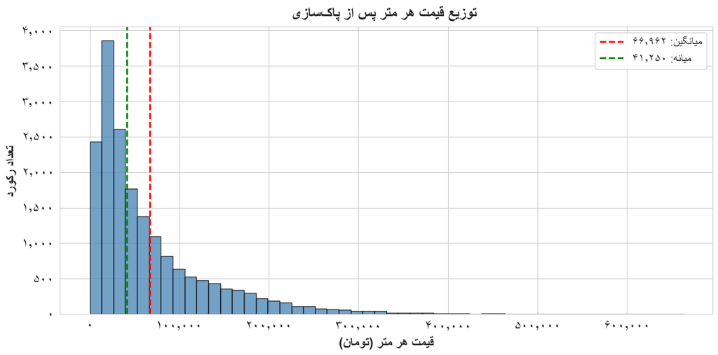

```python
# ========================================
# 5.1 هیستوگرام توزیع قیمت هر متر
# ========================================

# رسم نمودار هیستوگرام
fig, ax = plt.subplots(figsize=(12, 6))

ax.hist(df_clean['gheimat'], bins=50, color='steelblue', edgecolor='black', alpha=0.75)

# میانگین قیمت هر متر
mean_price = round(df_clean['gheimat'].mean())

# میانه قیمت هر متر
median_price = round(df_clean['gheimat'].median())

# رسم خطوط میانگین و میانه
ax.axvline(mean_price, color='red', linestyle='dashed', linewidth=2,
           label=persian_text(f"میانگین: {persian_number(mean_price)}"))

ax.axvline(median_price, color='green', linestyle='dashed', linewidth=2,
           label=persian_text(f"میانه: {persian_number(median_price)}"))

# تنظیمات محورها
ax.set_title(persian_text(' توزیع قیمت هر متر پس از پاک‌سازی'),
             fontsize=18, fontweight='bold', pad=10)
ax.set_xlabel(persian_text('قیمت هر متر (تومان)'), fontsize=16, fontweight='bold')
ax.set_ylabel(persian_text('تعداد رکورد'), fontsize=16, fontweight='bold')
ax.tick_params(axis='both', labelsize=16)

ax.xaxis.set_major_formatter(FuncFormatter(persian_axis))
ax.yaxis.set_major_formatter(FuncFormatter(persian_axis))

# اضافه کردن راهنمای نمودار
ax.legend(fontsize=14)

plt.tight_layout()
plt.savefig('price_distribution_histogram.png', dpi=1000, bbox_inches='tight')
plt.show()
```

هیستوگرام توزیع قیمت هر متر در کل کشور نشان می‌دهد که بیشتر معاملات در بازه‌های قیمتی پایین و متوسط متمرکز شده‌اند و با افزایش قیمت، تعداد معاملات به‌تدریج کاهش می‌یابد. در عین حال، وجود تعداد محدودی از املاک با قیمت‌های بسیار بالا موجب شده است که توزیع به سمت مقادیر بزرگ‌تر کشیده شود. همچنین قرار گرفتن میانگین در سطحی بالاتر از میانه نشان می‌دهد که این قیمت‌های بالا بر شاخص‌های مرکزی بازار مسکن تأثیر زیادی داشته‌اند.

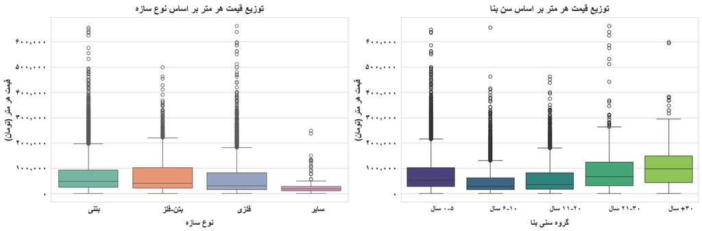

```python
# =================================================
# 5.2 نمودار جعبه‌ای قیمت هر متر بر اساس نوع سازه
# =================================================

# ایجاد شکل دو نمودار کنار هم
fig, axes = plt.subplots(1, 2, figsize=(18, 6))

# نام فارسی انواع سازه (بقیه در گروه "سایر")
skeleton_names = {'botoni': 'بتنی', 'botoni felezi': 'بتن-فلز', 'felezi': 'فلزی'}

# تبدیل نام انواع سازه به فارسی
df_clean['skeleton_fa'] = df_clean['eskelet'].map(skeleton_names)
df_clean['skeleton_fa'] = df_clean['skeleton_fa'].fillna('سایر')

# ترتیب نمایش بر اساس میانه قیمت
skeleton_order = (df_clean.groupby('skeleton_fa')['gheimat'].median().sort_values(ascending=False).index)

# رسم نمودار جعبه‌ای
sns.boxplot(data=df_clean, x='skeleton_fa', y='gheimat', order=skeleton_order,
            palette='Set2', ax=axes[0])

# تنظیمات محورها
axes[0].set_title(persian_text('توزیع قیمت هر متر بر اساس نوع سازه'),
                  fontsize=18, fontweight='bold', pad=10)
axes[0].set_xlabel(persian_text('نوع سازه'),
                   fontsize=16, fontweight='bold', labelpad=10)
axes[0].set_ylabel(persian_text('قیمت هر متر (تومان)'),
                   fontsize=16, fontweight='bold')

axes[0].yaxis.set_major_formatter(FuncFormatter(persian_axis))
axes[0].tick_params(axis='both', labelsize=16)

for label in axes[0].get_yticklabels():
    label.set_fontweight('bold')

axes[0].set_xticklabels([persian_text(label.get_text()) for label in axes[0].get_xticklabels()],
                        fontsize=16, fontweight='bold')

setup_rtl_axes(axes[0])

# =================================================
# 5.3 نمودار جعبه‌ای قیمت هر متر بر اساس سن بنا
# =================================================

# ایجاد گروه‌های سنی
df_clean['age_group'] = pd.cut(df_clean['omre bana'], bins=[-1, 5, 10, 20, 30, 100],
                               labels=['0-5', '6-10', '11-20', '21-30', '30+'])

# نام فارسی گروه‌ها
age_names = {'0-5': '۰-۵ سال', '6-10': '۶-۱۰ سال', '11-20': '۱۱-۲۰ سال', '21-30': '۲۱-۳۰ سال', '30+': '۳۰+ سال'}

# تبدیل نام گروه‌ها به فارسی
df_clean['age_fa'] = df_clean['age_group'].map(age_names)

# ترتیب نمایش
age_order = ['۰-۵ سال', '۶-۱۰ سال', '۱۱-۲۰ سال', '۲۱-۳۰ سال', '۳۰+ سال']

# رسم نمودار جعبه‌ای
sns.boxplot(data=df_clean, x='age_fa', y='gheimat', order=age_order,
            palette='viridis', ax=axes[1])

# تنظیمات محورها
axes[1].set_title(persian_text('توزیع قیمت هر متر بر اساس سن بنا'),
                  fontsize=18, fontweight='bold', pad=10)
axes[1].set_xlabel(persian_text('گروه سنی بنا'),
                   fontsize=16, fontweight='bold', labelpad=10)
axes[1].set_ylabel(persian_text('قیمت هر متر (تومان)'),
                   fontsize=16, fontweight='bold')

axes[1].yaxis.set_major_formatter(FuncFormatter(persian_axis))
axes[1].tick_params(axis='both', labelsize=16)

for label in axes[1].get_yticklabels():
    label.set_fontweight('bold')

axes[1].set_xticklabels([persian_text(label.get_text()) for label in axes[1].get_xticklabels()],
                        fontsize=14, fontweight='bold')

setup_rtl_axes(axes[1])

plt.tight_layout()
plt.savefig('boxplot_skeleton_age_country.png', dpi=1000, bbox_inches='tight')
plt.show()
```

وجود نقاط پرت در هر دو نمودار نشان می‌دهد که برخی املاک با قیمت‌هایی بسیار بالاتر از سطح معمول بازار معامله شده‌اند. این اختلاف قیمت می‌تواند ناشی از نقش عواملی مانند موقعیت مکانی، کیفیت ساخت و متراژ در تعیین قیمت ملک باشد.

##### 6. تحلیل استانی

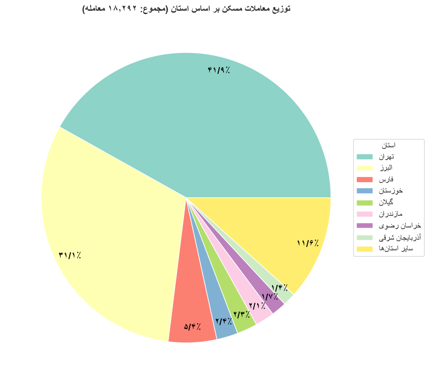

```python
# =================================================
# 6.1 نمودار دایره‌ای توزیع معاملات مسکن بر اساس استان
# =================================================

# محاسبه تعداد معاملات هر استان
state_counts = df_clean['State'].value_counts()

# نمایش ۸ استان اول (بقیه در گروه "سایر")
top_n = 8
top_states = state_counts.head(top_n)
others_count = state_counts[top_n:].sum()

# نام‌های فارسی استان‌ها
state_names_fa = {
    'Tehran': 'تهران', 'Alborz': 'البرز', 'Fars': 'فارس', 'Esfahan': 'اصفهان',
    'Mazandaran': 'مازندران', 'Khuzestan': 'خوزستان', 'Khorasan Razavi': 'خراسان رضوی',
    'East Azarbaijan': 'آذربایجان شرقی', 'Guilan': 'گیلان', 'Qom': 'قم'
}

# آماده‌سازی برچسب‌ها و مقادیر
labels = []
sizes = []

for state, count in top_states.items():
    labels.append(persian_text(state_names_fa.get(state, state)))
    sizes.append(count)

labels.append(persian_text('سایر استان‌ها'))
sizes.append(others_count)

# ایجاد فضای رسم نمودار
fig, ax = plt.subplots(figsize=(10, 8))

# ایجاد لیست رنگ‌ها
colors = plt.cm.Set3(np.linspace(0, 1, len(labels)))

# رسم نمودار دایره‌ای
wedges, texts, autotexts = ax.pie(sizes,
                                    labels=None,
                                    autopct=persian_pct,
                                    colors=colors,
                                    textprops={'fontsize': 11},
                                    pctdistance=0.9,
                                    center=(0,0.08))


# تنظیم رنگ و اندازه درصدها
for autotext in autotexts:
    autotext.set_color('black')
    autotext.set_fontweight('bold')
    autotext.set_fontsize(14)

# اضافه کردن راهنمای نمودار
ax.legend(wedges, labels,
          title=persian_text('استان'),
          loc='center left',
          bbox_to_anchor=(0.95, 0.5),
          fontsize=12,
          title_fontsize=12)

# عنوان نمودار
ax.set_title(persian_text(f'توزیع معاملات مسکن بر اساس استان (مجموع: {persian_number(len(df_clean))} معامله)'),
             fontsize=14, fontweight='bold')

plt.tight_layout()
plt.savefig('state_pie_chart_with_legend.png', dpi=1000, bbox_inches='tight')
plt.show()
```

نمودار دایره‌ای توزیع استان‌ها به‌خوبی نشان می‌دهد که داده‌های معاملات مسکن در ایران به‌شدت در استان تهران متمرکز است. این تمرکز بالا باید در تحلیل‌های بعدی مورد توجه قرار گیرد، زیرا ممکن است نتایج تحلیل‌ها تحت تأثیر وزن بالای داده‌های تهران قرار گیرد. برای تحلیل‌های دقیق‌تر، پیشنهاد می‌شود که داده‌های تهران به‌صورت جداگانه نیز مورد بررسی قرار گیرند که در بخش‌های بعدی این گزارش به آن پرداخته خواهد شد.

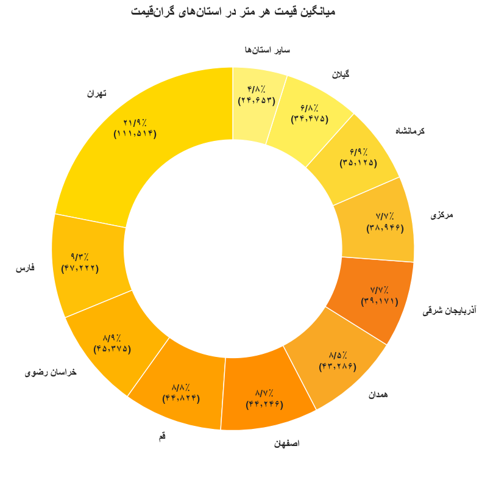

```python
# ========================================
# 6.2 دونات چارت استان‌های گران‌قیمت
# ========================================

# میانگین قیمت هر متر به تفکیک استان
state_avg_price = df_clean.groupby('ostan')['gheimat'].mean().sort_values(ascending=False)

# انتخاب ۱۰ استان با بیشترین میانگین قیمت
top10_price = state_avg_price.head(10)

# میانگین قیمت سایر استان‌ها
others_price = state_avg_price[10:].mean()
top10_price['سایر استان‌ها'] = others_price

# آماده‌سازی برچسب‌های نمودار
price_labels = [persian_text(name) for name in top10_price.index]

# ایجاد لیست رنگ‌ها
yellow_gold_colors = ['#FFD700', '#FFC107', '#FFB300', '#FFA000', '#FF8F00',
                      '#F9A825', '#F57F17', '#FBC02D', '#FDD835', '#FFEE58',
                      '#FFF176']

# ایجاد فضای رسم نمودار
plt.figure(figsize=(10, 8))

# رسم دونات چارت
wedges, texts, autotexts = plt.pie(
    top10_price,
    labels=price_labels,
    autopct=lambda pct: (f"{persian_pct(pct)}\n"f"({persian_number(pct/100 * sum(top10_price), 0)})"),
    colors=yellow_gold_colors[:len(top10_price)],
    startangle=90,
    pctdistance=0.85,
    textprops={'fontweight': 'bold'}
)

# تنظیم اندازه برچسب‌ها و درصدها
for txt, size in [(texts, 12), (autotexts, 12)]:
    for t in txt:
        t.set_fontsize(size)

# «جابه‌جایی برچسب «سایر استان‌ها
x, y = texts[-1].get_position()
texts[-1].set_position((x - 0.1, y))

# ایجاد دایره خالی مرکز نمودار
centre_circle = plt.Circle((0, 0), 0.60, fc='white')
plt.gca().add_artist(centre_circle)

# عنوان نمودار
plt.title(persian_text('میانگین قیمت هر متر در استان‌های گران‌قیمت'), fontsize=16, fontweight='bold')

plt.tight_layout()
plt.savefig('donut_price_top10_states_yellow.png', dpi=1000, bbox_inches='tight')
plt.show()
```

نمودار دوناتی میانگین قیمت هر متر در استان‌های گران‌قیمت به‌خوبی نشان می‌دهد که بازار مسکن ایران با نابرابری‌های جغرافیایی شدیدی مواجه است. تهران به‌عنوان مرکز سیاسی و اقتصادی کشور، قیمت‌های بسیار بالاتری نسبت به سایر استان‌ها دارد. این موضوع نشان می‌دهد که موقعیت جغرافیایی نقش مهمی در تعیین قیمت مسکن دارد. این امر می‌تواند پیامدهای اجتماعی و اقتصادی مهمی مانند مهاجرت معکوس، افزایش هزینه‌های زندگی و کاهش قدرت خرید خانوارها را به همراه داشته باشد.

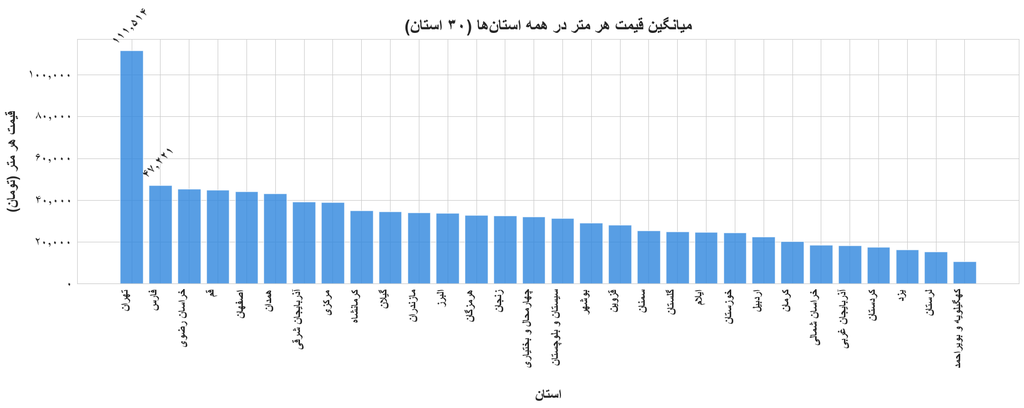

```
----------------------------------------
📊 آمار همه استان‌ها (به ترتیب قیمت)
----------------------------------------
1. تهران: 111,514 تومان
2. فارس: 47,221 تومان
3. خراسان رضوی: 45,374 تومان
4. قم: 44,823 تومان
5. اصفهان: 44,246 تومان
6. همدان: 43,285 تومان
7. آذربایجان شرقی: 39,170 تومان
8. مرکزی: 38,946 تومان
9. کرمانشاه: 35,124 تومان
10. گیلان: 34,475 تومان
11. مازندران: 34,138 تومان
12. البرز: 33,805 تومان
13. هرمزگان: 32,746 تومان
14. زنجان: 32,668 تومان
15. چهارمحال و بختیاری: 32,015 تومان
16. سیستان و بلوچستان: 31,453 تومان
17. بوشهر: 29,111 تومان
18. قزوین: 28,184 تومان
19. سمنان: 25,488 تومان
20. گلستان: 24,859 تومان
21. ایلام: 24,596 تومان
22. خوزستان: 24,367 تومان
23. اردبیل: 22,461 تومان
24. کرمان: 20,325 تومان
25. خراسان شمالی: 18,497 تومان
26. آذربایجان غربی: 18,322 تومان
27. کردستان: 17,519 تومان
28. یزد: 16,437 تومان
29. لرستان: 15,461 تومان
30. کهگیلویه و بویراحمد: 10,603 تومان
```

```python
# =================================================
# 6.3 نمودار میله‌ای میانگین قیمت همه استان‌ها
# =================================================

# میانگین قیمت هر متر به تفکیک استان
state_price = df_clean.groupby('State')['gheimat'].mean().sort_values(ascending=False)


# نام فارسی همه استان‌ها
state_names_fa = {
    'Tehran': 'تهران', 'Alborz': 'البرز', 'Fars': 'فارس', 'Esfahan': 'اصفهان',
    'Mazandaran': 'مازندران', 'Khuzestan': 'خوزستان', 'Khorasan Razavi': 'خراسان رضوی',
    'East Azarbaijan': 'آذربایجان شرقی', 'Guilan': 'گیلان', 'Qom': 'قم',
    'Western Azerbaijan': 'آذربایجان غربی', 'Kerman': 'کرمان', 'Yazd': 'یزد',
    'Central': 'مرکزی', 'Lorestan': 'لرستان', 'Kermanshah': 'کرمانشاه',
    'Golestan': 'گلستان', 'Zanjan': 'زنجان', 'Ardebil': 'اردبیل',
    'Kurdistan': 'کردستان', 'Hormozgan': 'هرمزگان', 'Bushehr': 'بوشهر',
    'Ilam': 'ایلام', 'Semnan': 'سمنان', 'Qazvin': 'قزوین',
    'Chaharmahal and Bakhtari': 'چهارمحال و بختیاری',
    'Kohgiluyeh Webir Ahmad': 'کهگیلویه و بویراحمد',
    'Sistan and Baluchistan': 'سیستان و بلوچستان',
    'North Khorasan': 'خراسان شمالی', 'South Khorasan': 'خراسان جنوبی','Hamedan':'همدان'
}

# آماده‌سازی داده‌ها برای نمودار
state_labels = [persian_text(state_names_fa.get(s, s)) for s in state_price.index]
state_prices = state_price.values

# ایجاد فضای رسم نمودار
fig, ax = plt.subplots(figsize=(20, 8))

# رسم نمودار میله‌ای
bars = ax.bar(range(len(state_labels)), state_prices, color='#2E86DE', alpha=0.8)

# تنظیمات محورها
ax.set_xticks(range(len(state_labels)))
ax.set_xticklabels(state_labels, rotation=90, ha='right', fontsize=16, fontweight='bold')
ax.tick_params(axis='y', labelsize=18)

count_fa = persian_number(len(state_price))
ax.set_title(persian_text(f'میانگین قیمت هر متر در همه استان‌ها ({count_fa} استان)'),
             fontsize=24, fontweight='bold', pad=10)
ax.set_xlabel(persian_text('استان'), fontsize=20, fontweight='bold', labelpad=30)
ax.set_ylabel(persian_text('قیمت هر متر (تومان)'), fontsize=20, fontweight='bold', labelpad=10)
ax.yaxis.set_major_formatter(FuncFormatter(persian_axis))

# راست‌چین کردن برچسب استان‌ها
for label in ax.get_xticklabels():
    label.set_horizontalalignment('right')

# افزودن مقادیر روی میله‌ها (فقط برای استان‌های بالای ۴۷٬۰۰۰ تومان)
for bar, price in zip(bars, state_prices):
    if price > 47000:
        price_fa = persian_number(int(price))
        ax.text(bar.get_x() + bar.get_width()/2, bar.get_height() + 3000, price_fa,
                ha='center', fontsize=18, fontweight='bold', rotation=45)

plt.tight_layout()
plt.savefig('all_states_bar_chart.png', dpi=1000, bbox_inches='tight')
plt.show()

# خلاصه آماری میانگین قیمت همه استان‌ها
print("\n" + "-" * 40)
print("📊 آمار همه استان‌ها (به ترتیب قیمت)")
print("-" * 40)

for i, (state, price) in enumerate(state_price.items(), 1):
    state_fa = state_names_fa.get(state, state)
    print(f"{i}. {state_fa}: {int(price):,} تومان")
```

نمودار میله‌ای میانگین قیمت همه استان‌ها، تصویر کاملی از نابرابری قیمت مسکن در ایران ارائه می‌دهد. شکاف عمیق بین تهران و سایر استان‌ها، مهمترین چالش بازار مسکن کشور است که نیازمند سیاست‌های متوازن‌کننده و توسعه متوازن مناطق مختلف می‌باشد. همچنین، وجود استان‌هایی با قیمت‌های بسیار پایین نشان‌دهنده پتانسیل رشد قیمت در این مناطق در صورت بهبود شرایط اقتصادی و زیرساختی است. این داده‌ها می‌تواند برای سرمایه‌گذاران، سیاست‌گذاران و محققان حوزه مسکن بسیار مفید باشد.

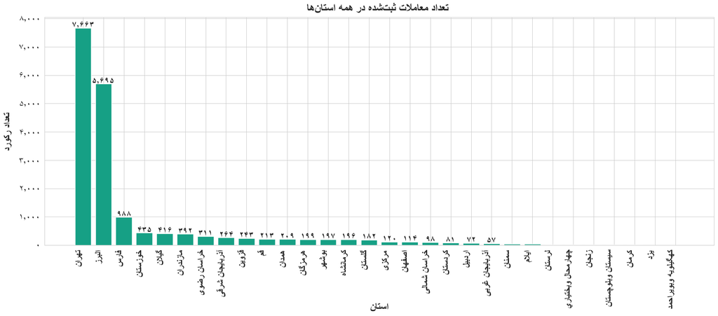

```
--------------------------------------------------
📊 خلاصه معاملات استان‌ها
--------------------------------------------------
بیشترین تعداد معاملات: تهران با 7,663 معامله
کمترین تعداد معاملات: كهگيلويه وبويراحمد با 1 معامله
اختلاف بیشترین و کمترین: 7,662 معامله

میانگین تعداد معاملات استان‌ها: 610 معامله
تعداد کل معاملات: 18,292

تعداد استان‌ها: 30
```

```python
# =================================================
# 6.4 نمودار میله‌ای تعداد معاملات در همه استان‌ها
# =================================================

# تعداد معامله به تفکیک استان
province_counts = df_clean['ostan'].value_counts().reset_index()
province_counts.columns = ['province', 'records']

# مرتب کردن نزولی
province_counts = province_counts.sort_values('records', ascending=False)

# آماده‌سازی داده‌ها برای نمودار
province_labels = [persian_text(p) for p in province_counts['province']]
counts = province_counts['records']

# ایجاد فضای رسم نمودار
fig, ax = plt.subplots(figsize=(18, 8))

# رسم نمودار میله‌ای
bars = ax.bar(province_labels, counts, color='#16A085')

# تنظیمات محورها
ax.set_xticks(range(len(province_labels)))
ax.set_xticklabels(province_labels, rotation=90, ha='right',
                   fontsize=16, fontweight='bold')
ax.tick_params(axis='y', labelsize=16)

ax.set_title(persian_text(f' تعداد معاملات ثبت‌شده در همه استان‌ها'),
             fontsize=20, fontweight='bold', pad=10)
ax.set_xlabel(persian_text('استان'), fontsize=18, fontweight='bold', labelpad=-10)
ax.set_ylabel(persian_text('تعداد رکورد'), fontsize=18, fontweight='bold', labelpad=10)
ax.yaxis.set_major_formatter(FuncFormatter(persian_axis))

# افزودن مقادیر روی میله‌ها
for bar, count in zip(bars, province_counts['records']):
    if count > 50:
        count_fa = persian_number(count)
        ax.text(bar.get_x() + bar.get_width()/2, bar.get_height() + 10, count_fa,
                ha='center', fontsize=16, fontweight='bold')

plt.tight_layout()
plt.savefig('all_provinces_counts.png', dpi=1000, bbox_inches='tight')
plt.show()

# خلاصه آماری تعداد معاملات همه استان‌ها
province_counts_sorted = province_counts.sort_values('records', ascending=False)

print("\n" + "-" * 50)
print("📊 خلاصه معاملات استان‌ها")
print("-" * 50)

print(f"بیشترین تعداد معاملات: {province_counts_sorted.iloc[0]['province']} "f"با {province_counts_sorted.iloc[0]['records']:,} معامله")
print(f"کمترین تعداد معاملات: {province_counts_sorted.iloc[-1]['province']} "f"با {province_counts_sorted.iloc[-1]['records']:,} معامله")
print(f"اختلاف بیشترین و کمترین: "f"{province_counts_sorted.iloc[0]['records'] - province_counts_sorted.iloc[-1]['records']:,} معامله")

print(f"\nمیانگین تعداد معاملات استان‌ها: "f"{province_counts_sorted['records'].mean():.0f} معامله")
print(f"تعداد کل معاملات: "f"{province_counts_sorted['records'].sum():,}")

print(f"\nتعداد استان‌ها: "f"{len(province_counts_sorted)}")
```

نمودار میله‌ای تعداد معاملات ثبت‌شده در همه استان‌ها، تصویر روشنی از توزیع فعالیت‌های بازار مسکن در سطح کشور ارائه می‌دهد. تمرکز شدید معاملات در تهران و چند استان بزرگ دیگر، نشان‌دهنده نابرابری جغرافیایی در بازار مسکن کشور است. این اطلاعات می‌تواند برای سیاست‌گذاران حوزه مسکن در شناسایی مناطقی که نیاز به توجه ویژه دارند و همچنین برای سرمایه‌گذاران در شناسایی بازارهای پرپتانسیل بسیار مفید باشد.

##### 7. تحلیل تهران

```python
# ========================================
# 7.1 استخراج داده‌های تهران
# ========================================

# فیلتر کردن داده‌ها فقط برای تهران
tehran_data = df_clean[df_clean['State'] == 'Tehran'].copy()

# حذف رکورهایی که منطقه ندارند
tehran_data = tehran_data[tehran_data['mantaghe'].notna()]

# تبدیل داده منطقه به عدد صحیح
tehran_data['mantaghe'] = tehran_data['mantaghe'].astype(int)

# میانگین قیمت هر متر برای هر منطقه و مرتب کردن نزولی
tehran_price = tehran_data.groupby('mantaghe')['gheimat'].mean().sort_values(ascending=False)

# خروجی آماری
print(f"\n📊 تعداد معاملات تهران: {len(tehran_data):,}")
print(f"📊 تعداد مناطق تهران: {len(tehran_price)}")
print(f"📊 محدوده قیمت: {int(tehran_price.min()):,} تا {int(tehran_price.max()):,} تومان")

# سهم تهران از کل داده‌ها
print(f"📊 سهم تهران از کل معاملات: %{len(tehran_data)/len(df_clean)*100:.1f}")
```

```
📊 تعداد معاملات تهران: 6,115
📊 تعداد مناطق تهران: 22
📊 محدوده قیمت: 58,019 تا 230,185 تومان
📊 سهم تهران از کل معاملات: %33.4
```

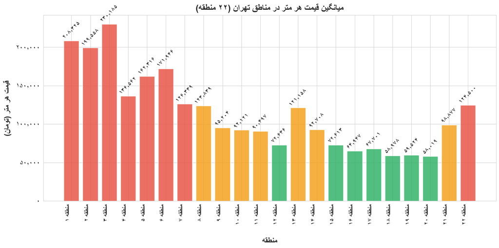

```
--------------------------------------------------
📊 خلاصه قیمت مناطق تهران
--------------------------------------------------
گران‌ترین منطقه: منطقه 3 با 230,185 تومان
ارزان‌ترین منطقه: منطقه 20 با 58,019 تومان
اختلاف قیمت: 172,166 تومان

میانگین قیمت مناطق تهران: 114,934 تومان

تعداد مناطق: 22
```

```python
# =================================================
# نمودار میله‌ای میانگین قیمت همه مناطق تهران 7.2
# =================================================

# میانگین قیمت هر منطقه (مرتب شده بر اساس شماره منطقه)
region_price = tehran_data.groupby('mantaghe')['gheimat'].mean().sort_index()

# آماده‌سازی داده‌ها برای نمودار
regions = [persian_text(f"منطقه {persian_number(int(r))}") for r in region_price.index]
prices = region_price.values

# ایجاد فضای رسم نمودار
fig, ax = plt.subplots(figsize=(16, 8))

# تقسیم مناطق به سه گروه قیمتی
q1 = region_price.quantile(0.33)
q2 = region_price.quantile(0.66)

colors = []

for price in prices:
    if price <= q1: colors.append('#27AE60')
    elif price <= q2: colors.append('#F39C12')
    else: colors.append('#E74C3C')

# رسم نمودار میله‌ای
bars = ax.bar(range(len(regions)), prices, color=colors, alpha=0.8)

# تنظیمات محورها
ax.set_xticks(range(len(regions)))
ax.set_xticklabels(regions, rotation=90, ha='right', fontsize=14, fontweight='bold')
ax.tick_params(axis='y', labelsize=16)

count_fa = persian_number(len(region_price))
ax.set_title(persian_text(f'میانگین قیمت هر متر در مناطق تهران ({count_fa} منطقه)'),
             fontsize=20, fontweight='bold', pad=10)
ax.set_xlabel(persian_text('منطقه'), fontsize=18, fontweight='bold', labelpad=30)
ax.set_ylabel(persian_text('قیمت هر متر (تومان)'), fontsize=18, fontweight='bold', labelpad=10)
ax.yaxis.set_major_formatter(FuncFormatter(persian_axis))

# افزودن مقادیر روی میله‌ها
for bar, price in zip(bars, prices):
    price_fa = persian_number(int(price))
    ax.text(bar.get_x() + bar.get_width()/2, bar.get_height() + 3000, price_fa,
            ha='center', fontsize=14, fontweight='bold', rotation=45)

plt.tight_layout()
plt.savefig('all_tehran_regions_bar.png', dpi=1000, bbox_inches='tight')
plt.show()

# خلاصه آماری میانگین قیمت مناطق تهران
region_price_sorted = region_price.sort_values(ascending=False)

print("\n" + "-" * 50)
print("📊 خلاصه قیمت مناطق تهران")
print("-" * 50)

print(f"گران‌ترین منطقه: منطقه {int(region_price_sorted.index[0])} "f"با {int(region_price_sorted.iloc[0]):,} تومان")
print(f"ارزان‌ترین منطقه: منطقه {int(region_price_sorted.index[-1])} "f"با {int(region_price_sorted.iloc[-1]):,} تومان")

print(f"اختلاف قیمت: "f"{int(region_price_sorted.iloc[0] - region_price_sorted.iloc[-1]):,} تومان")
print(f"\nمیانگین قیمت مناطق تهران: "f"{int(region_price.mean()):,} تومان")

print(f"\nتعداد مناطق: {len(region_price_sorted)}")
```

نمودار میله‌ای قیمت مناطق تهران، تصویر روشنی از نابرابری عمیق قیمت مسکن در پایتخت ارائه می‌دهد. الگوی شمال ـ جنوب قیمت‌ها نشان‌دهنده تأثیر بسیار قوی موقعیت مکانی بر قیمت مسکن است و شکاف قیمتی بین مناطق مختلف، یکی از مهمترین چالش‌های بازار مسکن تهران محسوب می‌شود. این داده‌ها می‌تواند برای خریداران، سرمایه‌گذاران و سیاست‌گذاران حوزه مسکن در اتخاذ تصمیمات آگاهانه بسیار مفید باشد. همچنین، تحلیل عمیق‌تر عوامل مؤثر بر این تفاوت‌ها می‌تواند موضوع پژوهش‌های آینده قرار گیرد.

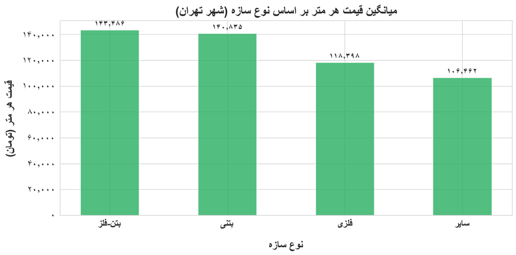

```
------------------------------------------------------------
📊 میانگین قیمت بر اساس نوع سازه در شهر تهران
------------------------------------------------------------
گران‌ترین سازه: بتن-فلز با 143,486 تومان
ارزان‌ترین سازه: سایر با 106,462 تومان
اختلاف قیمت: 37,024 تومان

میانگین قیمت انواع سازه: 127,295 تومان

پرتکرارترین سازه: بتنی با 3,323 رکورد
کم‌تکرارترین سازه: سایر با 20 رکورد
```

```python
# =================================================
# 7.3 نمودار میله‌ای اثر نوع سازه بر قیمت در تهران
# =================================================

# نام فارسی انواع سازه (بقیه در گروه "سایر")
skeleton_names = {'botoni': 'بتنی', 'botoni felezi': 'بتن-فلز', 'felezi': 'فلزی'}

# تبدیل نام انواع سازه به فارسی
tehran_data['skeleton_fa'] = tehran_data['eskelet'].map(skeleton_names)
tehran_data['skeleton_fa'] = tehran_data['skeleton_fa'].fillna('سایر')

# میانگین قیمت هر متر به تفکیک نوع سازه
skeleton_price = (tehran_data.groupby('skeleton_fa')['gheimat'].mean().sort_values(ascending=False))

# آماده‌سازی داده‌ها برای نمودار
skeleton_labels = [persian_text(sk) for sk in skeleton_price.index]
skeleton_prices = skeleton_price.values

# ایجاد فضای رسم نمودار
fig, ax = plt.subplots(figsize=(12, 6))

# رسم نمودار میله‌ای
bars = ax.bar(range(len(skeleton_labels)), skeleton_prices, width=0.5, color='#27AE60', alpha=0.8)

# تنظیمات محورها
ax.set_xticks(range(len(skeleton_labels)))
ax.set_xticklabels(skeleton_labels, fontsize=16, fontweight='bold')
ax.tick_params(axis='y', labelsize=16)

ax.set_title(persian_text(f'میانگین قیمت هر متر بر اساس نوع سازه (شهر تهران)'),
             fontsize=20, fontweight='bold', pad=10)


ax.set_xlabel(persian_text('نوع سازه'), fontsize=18, fontweight='bold', labelpad=20)
ax.set_ylabel(persian_text('قیمت هر متر (تومان)'), fontsize=18, fontweight='bold', labelpad=10)
ax.yaxis.set_major_formatter(FuncFormatter(persian_axis))

# افزودن مقادیر روی میله‌ها
for bar, price in zip(bars, skeleton_prices):
    price_fa = persian_number(int(price))
    ax.text(bar.get_x() + bar.get_width()/2, bar.get_height() + 3000, price_fa,
            ha='center', fontsize=14, fontweight='bold')

plt.tight_layout()
plt.savefig('skeleton_price_bar.png', dpi=1000)
plt.show()

# خلاصه آماری تأثیر  انواع سازه بر میانگین قیمت در تهران
skeleton_price_sorted = skeleton_price.sort_values(ascending=False)

print("\n" + "-" * 60)
print("📊 میانگین قیمت بر اساس نوع سازه در شهر تهران")
print("-" * 60)

print(f"گران‌ترین سازه: {skeleton_price_sorted.index[0]} "f"با {int(skeleton_price_sorted.iloc[0]):,} تومان")
print(f"ارزان‌ترین سازه: {skeleton_price_sorted.index[-1]} "f"با {int(skeleton_price_sorted.iloc[-1]):,} تومان")

print(f"اختلاف قیمت: "f"{int(skeleton_price_sorted.iloc[0] - skeleton_price_sorted.iloc[-1]):,} تومان")
print(f"\nمیانگین قیمت انواع سازه: "f"{int(skeleton_price.mean()):,} تومان")

# تعداد رکورد هر نوع سازه
skeleton_counts = tehran_data['skeleton_fa'].value_counts()

print(f"\nپرتکرارترین سازه: {skeleton_counts.index[0]} "f"با {skeleton_counts.iloc[0]:,} رکورد")
print(f"کم‌تکرارترین سازه: {skeleton_counts.index[-1]} "f"با {skeleton_counts.iloc[-1]:,} رکورد")
```

نمودار میله‌ای میانگین قیمت هر متر بر اساس نوع سازه در شهر تهران نشان می‌دهد که این متغیر نسبت به عواملی مانند منطقه شهری، تأثیر کمتری بر قیمت دارد. همچنین نتایج حاکی از آن است که سازه‌های بتنی و ترکیبی گران‌تر از سازه‌های فلزی و سایر هستند. بررسی فراوانی داده‌ها نشان می‌دهد که بیشترین تعداد معاملات مربوط به سازه‌های بتنی است، در حالی که گروه سایر سهم بسیار اندکی از داده‌ها را به خود اختصاص داده است.

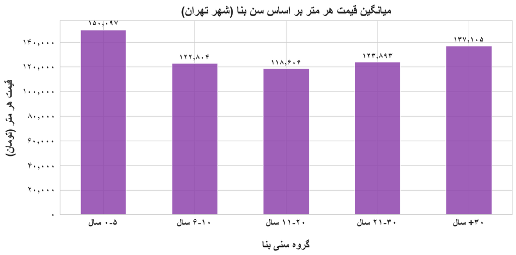

```
------------------------------------------------------------
📊 میانگین قیمت بر اساس سن بنا در شهر تهران
------------------------------------------------------------
گران‌ترین گروه سنی: ۰-۵ سال با 150,097 تومان
ارزان‌ترین گروه سنی: ۱۱-۲۰ سال با 118,606 تومان
اختلاف قیمت: 31,491 تومان

میانگین قیمت گروه‌های سنی: 130,501 تومان

بیشترین تعداد رکورد: ۰-۵ سال با 2,424 رکورد
کمترین تعداد رکورد: ۳۰+ سال با 241 رکورد
```

```python
# =================================================
# 7.4 نمودار میله‌ای اثر سن بنا بر قیمت در تهران
# =================================================

# ایجاد گروه‌های سنی
tehran_data['age_group'] = pd.cut(tehran_data['omre bana'], bins=[-1, 5, 10, 20, 30, 100],
                                  labels=['0-5', '6-10', '11-20', '21-30', '30+'])

# نام فارسی گروه‌ها
age_names = {'0-5': '۰-۵ سال', '6-10': '۶-۱۰ سال', '11-20': '۱۱-۲۰ سال', '21-30': '۲۱-۳۰ سال', '30+': '۳۰+ سال'}

# تبدیل نام گروه‌ها به فارسی
tehran_data['age_fa'] = tehran_data['age_group'].map(age_names)

# ترتیب نمایش
age_order = ['۰-۵ سال', '۶-۱۰ سال', '۱۱-۲۰ سال', '۲۱-۳۰ سال', '۳۰+ سال']

# میانگین قیمت هر متر بر اساس گروه سنی
age_price = (tehran_data.groupby('age_fa')['gheimat'].mean().reindex(age_order))

# آماده‌سازی داده‌ها برای نمودار
age_labels = [persian_text(a) for a in age_price.index]
age_prices = age_price.values

# ایجاد فضای رسم نمودار
fig, ax = plt.subplots(figsize=(12, 6))

# رسم نمودار میله‌ای
bars = ax.bar(range(len(age_labels)), age_prices, width=0.5, color='#8E44AD', alpha=0.85)

# تنظیمات محورها
ax.set_xticks(range(len(age_labels)))
ax.set_xticklabels(age_labels, fontsize=16, fontweight='bold')
ax.tick_params(axis='y', labelsize=16)

ax.set_title(persian_text('میانگین قیمت هر متر بر اساس سن بنا (شهر تهران)'),
             fontsize=20, fontweight='bold', pad=10)
ax.set_xlabel(persian_text('گروه سنی بنا'), fontsize=18, fontweight='bold', labelpad=20)
ax.set_ylabel(persian_text('قیمت هر متر (تومان)'), fontsize=18, fontweight='bold', labelpad=10)
ax.yaxis.set_major_formatter(FuncFormatter(persian_axis))

# نمایش مقادیر روی میله‌ها
for bar, price in zip(bars, age_prices):
    price_fa = persian_number(int(price))
    ax.text(bar.get_x() + bar.get_width()/2, bar.get_height() + 3000, price_fa,
            ha='center', fontsize=14, fontweight='bold')

plt.tight_layout()
plt.savefig('age_price_tehran_bar.png', dpi=1000)
plt.show()

# خلاصه آماری تأثیر گروه سنی بر میانگین قیمت در تهران
age_price_sorted = age_price.sort_values(ascending=False)

print("\n" + "-" * 60)
print("📊 میانگین قیمت بر اساس سن بنا در شهر تهران")
print("-" * 60)

print(f"گران‌ترین گروه سنی: {age_price_sorted.index[0]} با {int(age_price_sorted.iloc[0]):,} تومان")
print(f"ارزان‌ترین گروه سنی: {age_price_sorted.index[-1]} با {int(age_price_sorted.iloc[-1]):,} تومان")
print(f"اختلاف قیمت: {int(age_price_sorted.iloc[0] - age_price_sorted.iloc[-1]):,} تومان")
print(f"\nمیانگین قیمت گروه‌های سنی: {int(age_price.mean()):,} تومان")

# تعداد رکورد هر گروه
age_counts = tehran_data['age_fa'].value_counts().reindex(age_order)

print(f"\nبیشترین تعداد رکورد: {age_counts.idxmax()} با {age_counts.max():,} رکورد")
print(f"کمترین تعداد رکورد: {age_counts.idxmin()} با {age_counts.min():,} رکورد")
```

نمودار میله‌ای میانگین قیمت هر متر بر اساس سن بنا در شهر تهران نشان می‌دهد که واحدهای نوساز (۰ تا ۵ سال) بالاترین میانگین قیمت را دارند و با افزایش سن بنا، میانگین قیمت تا گروه سنی ۱۱ تا ۲۰ سال کاهش می‌یابد. پس از آن، در گروه‌های سنی بالاتر، دوباره میانگین قیمت روندی افزایشی پیدا می‌کند که می‌تواند ناشی از قرارگیری بخشی از این واحدها در مناطق قدیمی اما ارزشمند شهر تهران باشد. بررسی فراوانی داده‌ها نشان می‌دهد که بیشترین تعداد معاملات مربوط به واحدهای ۰ تا ۵ سال و کمترین تعداد مربوط به واحدهای با سن بیش از ۳۰ سال است.

##### 8. تحلیل زمانی

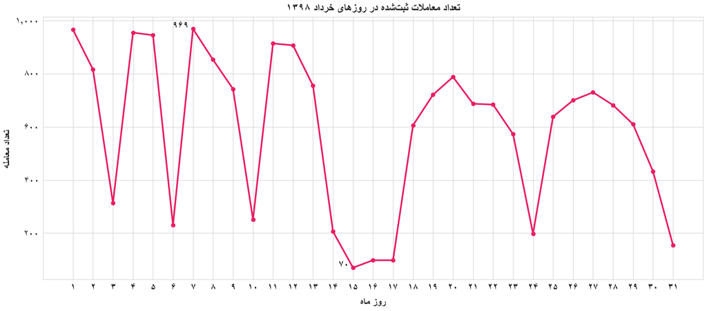

```
----------------------------------------
📊 خلاصه روند روزانه تعداد معاملات
----------------------------------------
تعداد روزهای دارای داده: 31
میانگین تعداد معامله: 590
بیشترین تعداد معامله: 969
کمترین تعداد معامله: 70

روز پرتراکنش: 7 (969 معامله)
روز کم‌تراکنش: 15 (70 معامله)
```

```python
# =================================================
# 8.1 نمودار خطی روند روزانه تعداد معاملات
# =================================================

# date استخراج روز از ستون
df_clean['date_str'] = df_clean['date'].astype(str)

# استخراج روز (بخش سوم بعد از /)
df_clean['day'] = df_clean['date_str'].str.split('/').str[2]

# تبدیل به عدد
df_clean['day'] = pd.to_numeric(df_clean['day'], errors='coerce')

# حذف روزهای خالی
df_day = df_clean.dropna(subset=['day']).copy()
df_day['day'] = df_day['day'].astype(int)

# تعداد معاملات در هر روز
daily_counts = df_day.groupby('day').size().reset_index(name='count')

# ایجاد جدول کامل روزهای ۱ تا ۳۱
all_days = pd.DataFrame({'day': range(1, 32)})
daily_full = all_days.merge(daily_counts, on='day', how='left')
daily_full['count'] = daily_full['count'].fillna(0).astype(int)

# ایجاد فضای رسم نمودار
fig, ax = plt.subplots(figsize=(18, 8))

# رسم نمودار خطی
ax.plot(daily_full['day'], daily_full['count'], marker='o',
        linewidth=3, markersize=7, color = '#E91E63')

# تنظیمات محورها
ax.set_title(persian_text('تعداد معاملات ثبت‌شده در روزهای خرداد ۱۳۹۸'),
             fontsize=20, fontweight='bold', pad=10)
ax.set_xlabel(persian_text('روز ماه'), fontsize=18, fontweight='bold', labelpad=10)
ax.set_ylabel(persian_text('تعداد معامله'), fontsize=18, fontweight='bold')

ax.set_xticks(range(1, 32))
ax.set_xticklabels([persian_number(i) for i in range(1, 32)],
                   fontsize=18, fontweight='bold')
ax.tick_params(axis='y', labelsize=18)
ax.yaxis.set_major_formatter(FuncFormatter(persian_axis))

# افزودن مقادیر روی نقاط کمینه و بیشینه
max_idx = daily_full['count'].idxmax()
min_idx = daily_full['count'].idxmin()

for idx, row in daily_full.iterrows():
    if idx in [max_idx, min_idx]:
        count_fa = persian_number(row['count'])
        ax.text(row['day'] - 0.2, row['count'], count_fa,
                ha='right', fontsize=18, fontweight='bold')

plt.tight_layout()
plt.savefig('daily_records_trend.png', dpi=1000, bbox_inches='tight')
plt.show()

# خلاصه آماری
print("\n" + "-" * 40)
print('📊 خلاصه روند روزانه تعداد معاملات')
print("-" * 40)

print(f'تعداد روزهای دارای داده: {len(daily_full[daily_full["count"] > 0])}')
print(f'میانگین تعداد معامله: {daily_full["count"].mean():,.0f}')
print(f'بیشترین تعداد معامله: {daily_full["count"].max():,.0f}')
print(f'کمترین تعداد معامله: {daily_full["count"].min():,.0f}')

if len(daily_full) > 0:
    max_day = daily_full.loc[daily_full['count'].idxmax()]
    min_day = daily_full.loc[daily_full['count'].idxmin()]

    print(f'\nروز پرتراکنش: 'f'{int(max_day["day"])} 'f'({max_day["count"]:,.0f} معامله)')
    print(f'روز کم‌تراکنش: 'f'{int(min_day["day"])} 'f'({min_day["count"]:,.0f} معامله)')
```

برای تحلیل دقیق‌تر، پیشنهاد می‌شود که این تحلیل در سطح ماهانه و فصلی نیز انجام شود تا الگوهای بلندمدت‌تر شناسایی گردند.

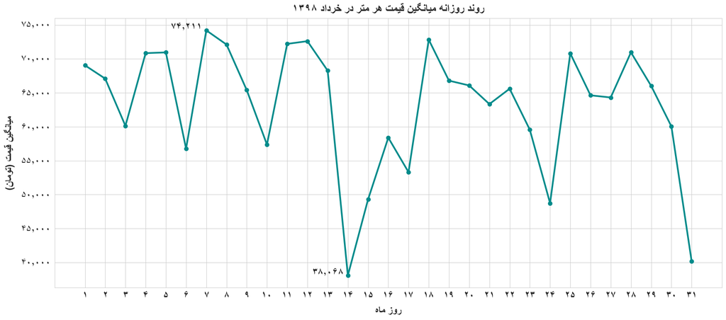

```
----------------------------------------
📊 خلاصه روند روزانه میانگین قیمت
----------------------------------------
تعداد روزهای دارای داده: 31

بیشترین میانگین قیمت: 74211 تومان
کمترین میانگین قیمت: 38068 تومان

گران‌ترین روز: 7 (74211 تومان)
ارزان‌ترین روز: 14 (38068 تومان)
```

```python
# =================================================
# 8.2 نمودار خطی روند روزانه میانگین قیمت
# =================================================

# میانگین قیمت و تعداد معامله هر روز
daily = df_day.groupby('day').agg(mean_price=('gheimat', 'mean'), records=('gheimat', 'count')).reset_index()

# ایجاد جدول کامل روزهای ۱ تا ۳۱
all_days = pd.DataFrame({'day': range(1, 32)})
daily_full = all_days.merge(daily, on='day', how='left')

daily_full['mean_price'] = daily_full['mean_price'].fillna(0)
daily_full['records'] = daily_full['records'].fillna(0).astype(int)

# فقط روزهای دارای داده
daily_has_data = daily_full[daily_full['mean_price'] > 0]

# ایجاد فضای رسم نمودار
fig, ax = plt.subplots(figsize=(18, 8))

# رسم نمودار خطی
ax.plot(daily_has_data['day'], daily_has_data['mean_price'], marker='o',
        linewidth=3, markersize=7, color='#008B8B')

# تنظیمات محورها
ax.set_title(persian_text('روند روزانه میانگین قیمت هر متر در خرداد ۱۳۹۸'),
             fontsize=20, fontweight='bold', pad=10)
ax.set_xlabel(persian_text('روز ماه'), fontsize=18, fontweight='bold', labelpad=10)
ax.set_ylabel(persian_text('میانگین قیمت (تومان)'), fontsize=18, fontweight='bold', labelpad=10)

ax.set_xticks(range(1, 32))
ax.set_xticklabels([persian_number(i) for i in range(1, 32)],
                   fontsize=18, fontweight='bold')
ax.tick_params(axis='y', labelsize=18)
ax.yaxis.set_major_formatter(FuncFormatter(persian_axis))

# افزودن مقادیر روی نقاط کمینه و بیشینه
max_idx = daily_has_data['mean_price'].idxmax()
min_idx = daily_has_data['mean_price'].idxmin()

for idx, row in daily_has_data.iterrows():
    if idx in [max_idx, min_idx]:
        price_fa = persian_number(round(row['mean_price']))
        ax.text(row['day']-0.2, row['mean_price'], price_fa,
                ha='right', fontsize=18, fontweight='bold')

plt.tight_layout()
plt.savefig('daily_price_trend.png', dpi=1000, bbox_inches='tight')
plt.show()

# خلاصه آماری
print("\n" + "-" * 40)
print('📊 خلاصه روند روزانه میانگین قیمت')
print("-" * 40)

print(f'تعداد روزهای دارای داده: 'f'{len(daily_has_data)}')
print(f'\nبیشترین میانگین قیمت: 'f'{round(daily_has_data["mean_price"].max())} تومان')
print(f'کمترین میانگین قیمت: 'f'{round(daily_has_data["mean_price"].min())} تومان')

if len(daily_has_data) > 0:
    max_day = daily_has_data.loc[daily_has_data['mean_price'].idxmax()]
    min_day = daily_has_data.loc[daily_has_data['mean_price'].idxmin()]

    print(f'\nگران‌ترین روز: 'f'{int(max_day["day"])} 'f'({round(max_day["mean_price"])} تومان)')
    print(f'ارزان‌ترین روز: 'f'{int(min_day["day"])} 'f'({round(min_day["mean_price"])} تومان)')
```

تحلیل روند روزانه قیمت مسکن نشان می‌دهد که قیمت‌ها در روزهای مختلف ماه دارای نوسانات قابل‌توجهی هستند. این اطلاعات می‌تواند برای موارد زیر مفید باشد:

- زمان‌بندی خرید و فروش: خریداران و فروشندگان می‌توانند با آگاهی از الگوی قیمتی، زمان مناسب‌تری را برای معامله انتخاب کنند.
- تحلیل بازار: شناسایی روزهای با قیمت پایین و بالا، می‌تواند به تحلیل عمیق‌تر بازار کمک کند.
- پیش‌بینی قیمت: با شناسایی الگوی روزانه، می‌توان قیمت روزهای آینده را با دقت بیشتری پیش‌بینی کرد.
- سیاست‌گذاری: سیاست‌گذاران حوزه مسکن می‌توانند از این اطلاعات برای طراحی سیاست‌های حمایتی در روزهای کم‌رونق استفاده کنند.

برای تحلیل دقیق‌تر، پیشنهاد می‌شود که این تحلیل در سطح ماهانه و فصلی نیز انجام شود تا الگوهای بلندمدت‌تر شناسایی گردند. همچنین بررسی تأثیر تعطیلات رسمی و رویدادهای خاص بر قیمت مسکن می‌تواند به درک بهتر این الگوها کمک کند.

##### 9. تحلیل رابطه بین متغیرها

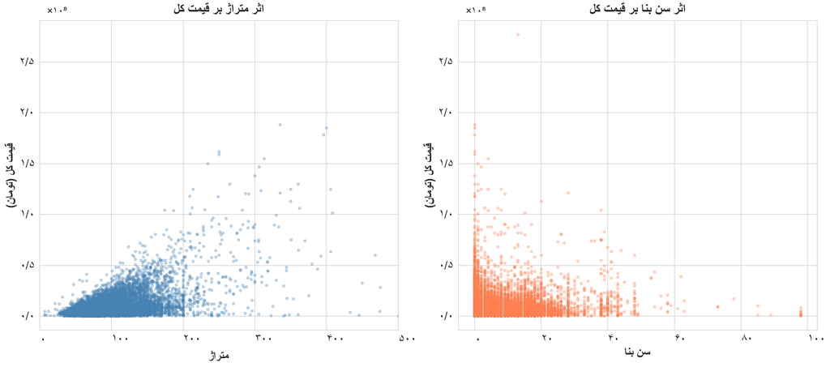

```python
# ========================================
# نمودار پراکندگی متراژ در برابر قیمت کل 9.1
# ========================================

# ایجاد شکل دو نمودار کنار هم
fig, axes = plt.subplots(1, 2, figsize=(18, 8))

# رسم نمودار پراکندگی
axes[0].scatter(df_clean['masahat'], df_clean['gheimat kol'],
                alpha=0.3, s=15, color='steelblue')

# تنظیمات محورها
axes[0].set_title(persian_text('اثر متراژ بر قیمت کل'),
                  fontsize=20, fontweight='bold', pad=10)
axes[0].set_xlabel(persian_text('متراژ'), fontsize=18, fontweight='bold', labelpad=10)
axes[0].set_ylabel(persian_text('قیمت کل (تومان)'), fontsize=18, fontweight='bold')

axes[0].tick_params(axis='both', labelsize=18)
axes[0].set_xlim(0, 500)

axes[0].xaxis.set_major_formatter(FuncFormatter(persian_axis))
axes[0].yaxis.set_major_formatter(FuncFormatter(lambda x, pos: persian_number(x / 1e8, 1)))
axes[0].text(0.02, 1.02, "×۱۰⁸", transform=axes[0].transAxes,
             fontsize=16)

setup_rtl_axes(axes[0])

# ========================================
# نمودار پراکندگی سن بنا در برابر قیمت کل 9.2
# ========================================

# رسم نمودار پراکندگی
axes[1].scatter(df_clean['omre bana'], df_clean['gheimat kol'],
                alpha=0.3, s=15, color='coral')

axes[1].set_title(persian_text('اثر سن بنا بر قیمت کل'),
                  fontsize=20, fontweight='bold', pad=10)
axes[1].set_xlabel(persian_text('سن بنا'), fontsize=18, fontweight='bold')
axes[1].set_ylabel(persian_text('قیمت کل (تومان)'), fontsize=18, fontweight='bold')

axes[1].tick_params(axis='both', labelsize=18)

axes[1].xaxis.set_major_formatter(FuncFormatter(persian_axis))
axes[1].yaxis.set_major_formatter(FuncFormatter(lambda x, pos: persian_number(x / 1e8, 1)))
axes[1].text(0.02, 1.02, "×۱۰⁸", transform=axes[1].transAxes,
             fontsize=16)

setup_rtl_axes(axes[1])

plt.tight_layout()
plt.savefig('relationship_total_price.png', dpi=1000, bbox_inches='tight')
plt.show()
```

تحليل اثر متراژ و سن بنا بر قيمت مسكن نشان می‌دهد كه بين اين متغيرها رابطه كاملاً خطی وجود ندارد. پراكندگی زياد در هر دو نمودار نشان می‌دهد كه برای قيمت‌گذاری دقيق مسكن، بايد به مجموعه‌ای از عوامل توجه کرد و نمی‌توان تنها بر اساس یک یا دو متغیر تصمیم‌گیری نمود. این تحلیل می‌تواند برای قیمت‌گذاری ملک، ارزیابی سرمایه‌گذاری و تحليل بازار مسكن مورد استفاده قرار گيرد.

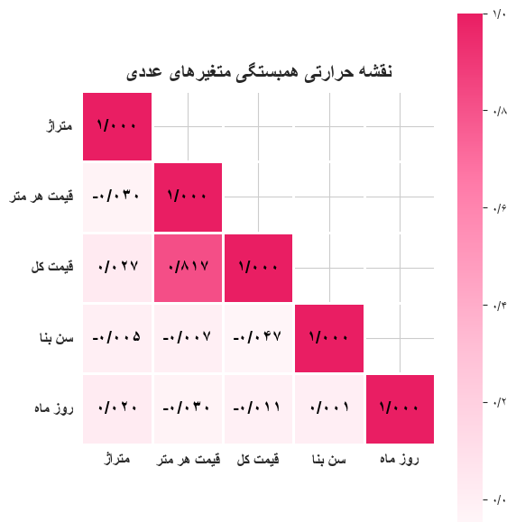

```
------------------------------------------------------------
📊 ضرایب همبستگی متغیرها
------------------------------------------------------------
             masahat  gheimat  gheimat kol  omre bana   day
masahat         1.00    -0.03         0.03      -0.01  0.02
gheimat        -0.03     1.00         0.82      -0.01 -0.03
gheimat kol     0.03     0.82         1.00      -0.05 -0.01
omre bana      -0.01    -0.01        -0.05       1.00  0.00
day             0.02    -0.03        -0.01       0.00  1.00

------------------------------------------------------------
📊 قوی‌ترین همبستگی (به جز قطر اصلی)
------------------------------------------------------------
قیمت هر متر و قیمت کل
ضریب همبستگی: 0.817
```

```python
# ========================================
# 9.3 نقشه حرارتی همبستگی متغیرهای عددی
# ========================================

# انتخاب متغیرهای عددی
corr_columns = ['masahat', 'gheimat', 'gheimat kol', 'omre bana', 'day']

# نام فارسی متغیرها
column_names = {'masahat': 'متراژ', 'gheimat': 'قیمت هر متر', 'gheimat kol': 'قیمت کل', 'omre bana': 'سن بنا', 'day': 'روز ماه'}

# ماتریس همبستگی پیرسون
corr = df_clean[corr_columns].corr()

# ایجاد متن فارسی برای نمایش داخل خانه‌ها
annot_labels = corr.copy()

for i in range(corr.shape[0]):
    for j in range(corr.shape[1]): annot_labels.iloc[i, j] = persian_number(corr.iloc[i, j], 3)

# ایجاد شکل نمودار
fig, ax = plt.subplots(figsize=(6, 6))

# تعریف طیف رنگی سفارشی
pink_map = LinearSegmentedColormap.from_list("pink_map", ["#fff5f8", "#ffc0d6", "#ff7aa8", "#e91e63"])

# ماسک برای مخفی کردن مثلث بالایی
mask = np.triu(np.ones_like(corr, dtype=bool), k=1)

# رسم نمودار نقشه حرارتی
sns.heatmap(corr, mask=mask, annot=annot_labels, fmt='', cmap=pink_map, square=True,
            linewidths=1, cbar=True, ax=ax, annot_kws={'fontsize': 14, 'fontweight': 'bold', 'color': 'black'})

# فارسی کردن اعداد نوار راهنما
cbar = ax.collections[0].colorbar
cbar.ax.yaxis.set_major_formatter(FuncFormatter(lambda x, pos: persian_number(x, 1)))

# آماده‌سازی برچسب‌ها برای نمودار
labels = [persian_text(column_names[col]) for col in corr_columns]

# تنظیمات محورها
ax.set_xticklabels(labels, rotation=0, fontsize=12, fontweight='bold')
ax.set_yticklabels(labels, rotation=0, fontsize=12, fontweight='bold')

ax.set_title(persian_text('نقشه حرارتی همبستگی متغیرهای عددی'),
             fontsize=16, fontweight='bold', pad=10)

plt.tight_layout()
plt.savefig('correlation_heatmap.png', dpi=1000, bbox_inches='tight')
plt.show()

# خلاصه آماری
print("\n" + "-" * 60)
print("📊 ضرایب همبستگی متغیرها")
print("-" * 60)
print(corr.round(3))

# قوی‌ترین همبستگی (به جز قطر اصلی)
corr_abs = corr.abs().copy()

np.fill_diagonal(corr_abs.values, 0)

max_pair = corr_abs.stack().idxmax()
max_value = corr.loc[max_pair]

print("\n" + "-" * 60)
print("📊 قوی‌ترین همبستگی (به جز قطر اصلی)")
print("-" * 60)
print(f"{column_names[max_pair[0]]} و {column_names[max_pair[1]]}")
print(f"ضریب همبستگی: {max_value:.3f}")
```

بيشترين همبستگی خطی بين قيمت هر متر و قيمت كل مشاهده می‌شود و ساير متغیرهای عددی همبستگی خطی بسيار ضعيفی با هم دارند. اين تحليل می‌تواند برای شناسايی متغيرهای مؤثر، انتخاب ويژگی و بررسی ارتباط خطی بين متغيرهای بازار مسكن مورد استفاده قرار گيرد.

##### 10. تحلیل عوامل مؤثر بر قیمت مسکن

```python
# =================================================
# 10.1 Random Forest استخراج اهمیت ویژگی‌ها با مدل
# =================================================

# ایجاد کپی از داده‌های پاک‌سازی‌شده
df_model = df_clean.copy()

# تبدیل متغیرهای دسته‌ای به رشته
df_model['State'] = df_model['State'].astype(str)
df_model['City'] = df_model['City'].astype(str)
df_model['eskelet'] = df_model['eskelet'].astype(str)

# کدگذاری برای تبدیل مقادیر متنی به عددی
le_state, le_city, le_region, le_skeleton = LabelEncoder(), LabelEncoder(), LabelEncoder(), LabelEncoder()

# تبدیل به مقادیر عددی
df_model['State_Code'] = le_state.fit_transform(df_model['State'])
df_model['City_Code'] = le_city.fit_transform(df_model['City'])
df_model['Skeleton_Code'] = le_skeleton.fit_transform(df_model['eskelet'])

# انتخاب متغیرهای ورودی مدل
features = ['masahat', 'omre bana', 'day', 'State_Code', 'City_Code', 'Skeleton_Code']
feature_names_fa = ['متراژ', 'سن بنا', 'روز ماه', 'استان', 'شهر', 'نوع سازه']

# تعریف ورودی و هدف مدل
X, y = df_model[features], df_model['gheimat']

# ایجاد مدل جنگل تصادفی با ۱۰۰ درخت تصمیم
rf_model = RandomForestRegressor(n_estimators=100, random_state=42)

# آموزش مدل
rf_model.fit(X, y)

# (R² Score) ارزیابی مدل
print(f"\n📊 دقت مدل (R²): {rf_model.score(X, y):.4f}")

# استخراج و نمایش میزان اهمیت هر متغیر در پیش‌بینی قیمت هر متر
print("\n" + "-" * 40)
print("📊 اهمیت ویژگی‌ها")
print("-" * 40)
importances = rf_model.feature_importances_

feature_importance_pairs = list(zip(feature_names_fa, importances))
feature_importance_pairs = sorted(feature_importance_pairs, key=lambda x: x[1], reverse=True)

for name, imp in feature_importance_pairs:
    print(f"  %{name}: {imp * 100: .1f}")
```

```
📊 دقت مدل (R²): 0.9429

----------------------------------------
📊 اهمیت ویژگی‌ها
----------------------------------------
  %شهر:  50.5
  %متراژ:  27.9
  %روز ماه:  9.6
  %سن بنا:  8.9
  %نوع سازه:  2.3
  %استان:  0.8
```

این مدل برای تخمین قیمت مسکن و بررسی میزان اهمیت عوامل مختلف بر آن مورد استفاده قرار می‌گیرد. با این حال، نتایج به‌دست‌آمده صرفاً یک ارزیابی اولیه محسوب می‌شوند و برای تخمین دقیق‌تر، نیاز به بهبودهایی مانند تفکیک داده‌ها، تنظیم پارامترهای مدل و اعتبارسنجی دقیق‌تر وجود دارد.

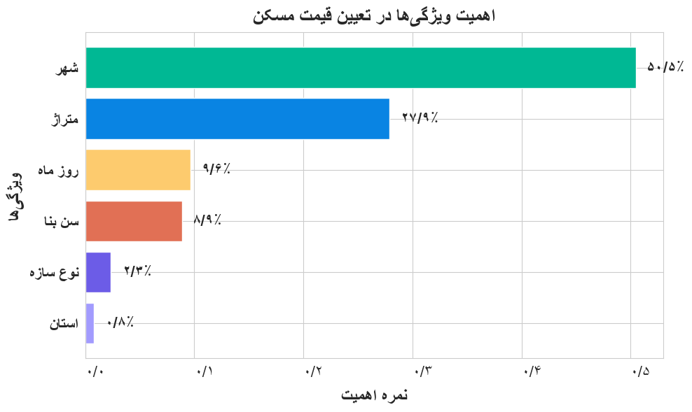

```python
# ========================================
# 10.2 نمودار اهمیت ویژگی‌ها در پیش‌بینی قیمت
# ========================================

# ایجاد شکل نمودار
fig, ax = plt.subplots(figsize=(10, 6))

# تعریف رنگ برای هر ویژگی
colors = ['#00B894', '#0984E3', '#FDCB6E', '#E17055', '#6C5CE7', '#A29BFE']

# مرتب کردن نزولی بر اساس میزان اهمیت ویژگی‌ها
indices = np.argsort(importances)[::-1]

# استخراج نام و مقدار اهمیت به ترتیب مرتب‌شده
sorted_names = [feature_names_fa[i] for i in indices]
sorted_imps = [importances[i] for i in indices]

# تبدیل نام ویژگی‌ها به فارسی
sorted_names_display = [persian_text(name) for name in sorted_names]

# رسم نمودار میله‌ای افقی
bars = ax.barh(range(len(sorted_imps)), sorted_imps, align='center', color=colors)

# تنظیمات محوورها
ax.set_yticks(range(len(sorted_imps)))
ax.set_yticklabels(sorted_names_display)
ax.tick_params(axis='both', labelsize=16)

ax.set_title(persian_text('اهمیت ویژگی‌ها در تعیین قیمت مسکن'), fontsize=20, fontweight='bold', pad=10)
ax.set_xlabel(persian_text('نمره اهمیت'), fontsize=18, fontweight='bold', labelpad=10)
ax.set_ylabel(persian_text('ویژگی‌ها'), fontsize=18, fontweight='bold')
ax.xaxis.set_major_formatter(FuncFormatter(lambda x, pos: persian_number(x, 1)))
for label in ax.get_yticklabels():
    label.set_fontweight('bold')

ax.invert_yaxis()

setup_rtl_axes(ax)

# افزودن درصد روی میله‌ها
for i, (bar, imp) in enumerate(zip(bars, sorted_imps)):
    ax.text(imp + 0.01, bar.get_y() + bar.get_height()/2, persian_pct(imp * 100),
            va='center', fontsize=16, fontweight='bold')

plt.tight_layout()
plt.savefig('feature_importance.png', dpi=1000, bbox_inches='tight')
plt.show()
```

این نتایج نشان می‌دهند که «شهر» مهم‌ترین ویژگی در پیش‌بینی قیمت مسکن است و پس از آن، متراژ بیشترین اهمیت را دارد. سایر ویژگی‌ها در پیش‌بینی قیمت نقش دارند، اما میزان تأثیر آن‌ها کمتر است. این یافته‌ها می‌تواند به خریداران، سرمایه‌گذاران و سیاست‌گذاران در اتخاذ تصمیمات آگاهانه‌تر کمک کند.

##### 11.نمودار تعاملی روزانه میانگین قیمت استان‌ها

```python
try:
    import plotly.graph_objects as go
    import plotly.io as pio

    # نام فارسی استان‌ها
    state_names_fa = {
        'Tehran': 'تهران', 'Alborz': 'البرز', 'Fars': 'فارس', 'Esfahan': 'اصفهان',
        'Mazandaran': 'مازندران', 'Khuzestan': 'خوزستان', 'Khorasan Razavi': 'خراسان رضوی',
        'East Azarbaijan': 'آذربایجان شرقی', 'Guilan': 'گیلان', 'Qom': 'قم',
        'Western Azerbaijan': 'آذربایجان غربی', 'Kerman': 'کرمان', 'Yazd': 'یزد',
        'Central': 'مرکزی', 'Lorestan': 'لرستان', 'Kermanshah': 'کرمانشاه',
        'Golestan': 'گلستان', 'Zanjan': 'زنجان', 'Ardebil': 'اردبیل',
        'Kurdistan': 'کردستان', 'Hormozgan': 'هرمزگان', 'Bushehr': 'بوشهر',
        'Ilam': 'ایلام', 'Semnan': 'سمنان', 'Qazvin': 'قزوین',
        'Chaharmahal and Bakhtari': 'چهارمحال و بختیاری',
        'Kohgiluyeh Webir Ahmad': 'کهگیلویه و بویراحمد',
        'Sistan and Baluchistan': 'سیستان و بلوچستان',
        'North Khorasan': 'خراسان شمالی', 'South Khorasan': 'خراسان جنوبی',
        'Hamedan': 'همدان'
    }

    # آماده‌سازی داده‌هاي روزانه بر اساس استان
    daily_province = (df_day.groupby(["State", "day"]).agg(mean_price=("gheimat", "mean")).reset_index().sort_values(["State", "day"]))

    # استخراج لیست استان‌‌ها
    states = sorted(daily_province["State"].unique())

    # انتخاب استان پیش‌فرض
    default_state = states[0]
    df0 = daily_province[daily_province["State"] == default_state]

    # رنگ‌های نمودار
    LINE_COLOR, POINT_COLOR = "#118DFF", "#D13438"
    BG_COLOR, GRID_COLOR = "#FFFFFF", "#EDEBE9"
    TEXT_COLOR, AXIS_COLOR = "#605E5C", "#605E5C"

    # رسم نمودار اولیه
    fig = go.Figure()

    fig.add_trace(go.Scatter(
        x=df0["day"], y=df0["mean_price"],
        mode="lines+markers",
        line={"color": LINE_COLOR, "width": 4},
        marker={"size": 9, "color": POINT_COLOR},
        hovertemplate="روز: %{customdata}<br>قیمت: %{text} تومان<extra></extra>",
        customdata=[persian_number(i) for i in df0['day']],
        text=[persian_number(round(i)) for i in df0['mean_price']]
    ))

    # دکمه‌های تعاملی انتخاب استان
    buttons = [{"label": state_names_fa.get(s, s), "method": "update",
                "args": [{"x": [daily_province[daily_province["State"] == s]["day"]],
                          "y": [daily_province[daily_province["State"] == s]["mean_price"]]},
                         {"title.text": f"نمودار تعاملی قیمت در استان {state_names_fa.get(s, s)}"}]}
               for s in states]

    #  y فارسی کردن محور
    step = 5000
    y_ticks = np.arange(0, daily_province["mean_price"].max() + step, step)

    ticktext = [persian_number(int(v/1000)) + "k" if v >= 1000 else "۰"
            for v in y_ticks]

    # تنظیمات نمودار
    fig.update_layout(
        template="plotly_white", paper_bgcolor=BG_COLOR, plot_bgcolor=BG_COLOR,
        height=520, width=900,
        font={"family": "Vazirmatn, Vazir, IRANSans, Tahoma, Arial", "size": 16, "color": TEXT_COLOR},
        title={"text": f"نمودار تعاملی قیمت مسکن در استان {state_names_fa.get(default_state, default_state)}",
               "x": 0.5, "font": {"size": 24, "color": LINE_COLOR}},

        # x تنظیمات محور
        xaxis={"title": "روز ماه", "title_font": {"size": 18, "color": TEXT_COLOR},
               "tickfont": {"size": 16, "color": AXIS_COLOR}, "tickangle":0, "tickmode": "array",
               "tickvals": list(range(1, 32, 2)), "ticktext": [persian_number(i) for i in range(1, 32, 2)],
               "showline": True, "linecolor": AXIS_COLOR, "linewidth": 3,
               "ticks": "outside", "tickwidth": 2, "tickcolor": AXIS_COLOR,
               "showgrid": True, "gridcolor": GRID_COLOR},

        # y تنظیمات محور
        yaxis={"title": "میانگین قیمت هر متر (تومان)", "title_font": {"size": 18, "color": TEXT_COLOR},
               "tickfont": {"size": 16, "color": AXIS_COLOR}, "tickmode": "array",
                "tickvals": y_ticks, "ticktext": ticktext,
                "showline": True, "linecolor": AXIS_COLOR, "linewidth": 3,
               "ticks": "outside", "tickwidth": 2, "tickcolor": AXIS_COLOR,
               "showgrid": True, "gridcolor": GRID_COLOR},

        # منوی انتخاب استان
        updatemenus=[{"buttons": buttons,  "direction": "down", "x": 0.01, "y": 1.15,
                      "bgcolor": "#F8FAFC", "bordercolor": AXIS_COLOR,
                      "font": {"color": AXIS_COLOR, "size": 17}, "showactive": True}]
    )

    # تنظیمات رندر و نمایش نمودار
    config = {"displayModeBar": True, "displaylogo": False,
              "modeBarButtonsToAlwaysShow": ["zoom2d", "pan2d", "resetScale2d", "toImage"]}

    # قالب سفارشی پس‌زمینه
    pio.templates["custom_theme"] = go.layout.Template(
        layout=dict(paper_bgcolor=BG_COLOR, plot_bgcolor=BG_COLOR)
    )

    fig.update_layout(template="custom_theme")

    # ذخیره نمودار تعاملی
    fig.write_html("House_Interactive_plot.html", include_plotlyjs="cdn", full_html=True,
                   config={"displayModeBar": True, "displaylogo": False,
                           "modeBarButtonsToAlwaysShow": ["zoom2d", "pan2d", "resetScale2d", "toImage"]})

    print("✅ نمودار ذخیره شد: House_Interactive_plot.html")

    display(IFrame("House_Interactive_plot.html", width=1000, height=600))

    # PNG ذخیره به صورت
    fig.write_image("House_Interactive_plot.png", width=1200, height=700, scale=3)

    print("✅ نمودار PNG ذخیره شد: House_Interactive_plot.png")

# مدیریت خطا در صورت نبود کتابخانه یا داده
except Exception as e:
    print("خطا:", e)
```

```
✅ نمودار ذخیره شد: House_Interactive_plot.html
```

[interactive chart not shown]

```
✅ نمودار PNG ذخیره شد: House_Interactive_plot.png
```